# Learning to Learn: metacognition and the coalesce() function

Jesse

2019-03-28

## The challenge

One skill that all great educators possess is the ability to ask questions. Asking the right questions at the right time of the learners in your classroom can facilitate understanding, uncover misconceptions, and indicate whether or not learners have mastered the material.

However, when you’re learning on your own you have to simultaneously fill the roles of both learner and educator, and not only know both how and when to ask yourself questions, but also answer your questions, evaluate your answers, and redirect your learning path as you progress.

## Encountering coalesce

Rather than rehash all the ways that one can develop and deliver questions (check out [Doug Lemov’s “Teach Like a Champion 2.0”](https://teachlikeachampion.com/books/teach-like-champion-2-0) if you’re interested in more information), I wanted to do a quick walkthrough of both my code as well as thought process when I encountered the `coalesce()` function this evening.

I noticed use of the `coalesce()` function while I was reading through [the vignette for the `janitor` package](https://github.com/sfirke/janitor):

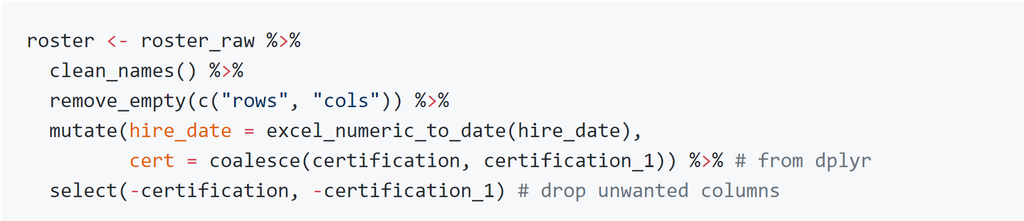

**Thought:** hmm. I’ve definitely *seen* `coalesce()` before, but I don’t know what it does.

**Action:** open RStudio and run the following code:

```r
# install the dplyr package if you don't have it
# install.packages(dplyr)

# load the dplyr package into your workspace
library(dplyr)

# pull up the Help page for the coalesce function
?coalesce
```

Once I’ve got the `coalesce()` Help page open I’ve got some good information at my disposal. The title and description give me some clue as to what’s happening in this function.

**Question to self:** based on the information in the title and description, could you explain to someone what the `coalesce()` function does?

*lolnope!*

## Inside my brain case: exploring `coalesce()`

OK, let’s look at what the first example in the Help documentation does:

```r
x <- sample(c(1:5, NA, NA, NA))
coalesce(x, 0L)
```

```
## [1] 2 5 0 3 4 1 0 0
```

I think that makes sense. I know that `sample()` is going to give me eight values with three `NA` values and the numbers 1 - 5.

**But what happens if I use an integer besides 0?**  
I’m wondering if the 0L is replacing the `NA` values with 0. If that’s the case, then the `NA` values should be replaced with any integer that I feed into the `coalesce()` function. Let’s use an intentionally larger number so that it’s easy to visually discern:

```r
coalesce(x, 928L)
```

```
## [1]   2   5 928   3   4   1 928 928
```

That works!

**What happens if I use different values to replace the `NA` values?**  
I’m assuming that I can only use integers since I’m working with [vectors instead of lists](http://adv-r.had.co.nz/Data-structures.html), but let’s check that assumption with a character string:

```r
coalesce(x, "rabbit")
```

```
## Error: Can't combine `..1` <integer> and `..2` <character>.
```

What about a double?

```r
coalesce(x, 9.8)
```

```
## [1] 2.0 5.0 9.8 3.0 4.0 1.0 9.8 9.8
```

OK, but do I *really* have to specify an integer?

```r
coalesce(x, 5)
```

```
## [1] 2 5 5 3 4 1 5 5
```

Let’s confirm:

```r
coalesce(x, 5L)
```

```
## [1] 2 5 5 3 4 1 5 5
```

Great! I feel comfortable with the first worked example, but want to check out the second, because it looks like something I could use in my own work:

```r
y <- c(1, 2, NA, NA, 5)
z <- c(NA, NA, 3, 4, 5)
coalesce(y, z)
```

```
## [1] 1 2 3 4 5
```

**Is the `NA` in one vector being replaced by a numerical value in the other vector?**

I’m 98% confident that this is the case, but let’s double check:

```r
a <- c(1, NA, 5)
b <- c(22, 24, 26)
coalesce(a, b)
```

```
## [1]  1 24  5
```

**But what happens if I have two `NA` values, both at the same position in each vector?**

What I *think* will happen is that I’ll get an `NA` value, because there isn’t anything other than an `NA` available to replace the existing `NA`.

```r
c <- c(1, NA, 5)
d <- c(2, NA, 4)
coalesce(c, d)
```

```
## [1]  1 NA  5
```

**What happens if I have `NA` values in both vectors, but in different positions?**

I assume that I’ll be left with a vector comprised entirely of integers, and I’m *guessing* that the `NA` value in `e` will be replaced with the **24** from `f`:

```r
e <- c(1, NA, 5)
f <- c(NA, 24, 26)
coalesce(e, f)
```

```
## [1]  1 24  5
```

Based on these results it seems that the order in which I supply the vectors to the `coalesce()` function matters. This isn’t entirely surprising - this is how R behaves - but I want to confirm this finding.

**What if I reverse the order of vectors provided to the `coalesce()` function?**

My assumption is that I’ll see the *first* `NA` value from `f` replaced with **1** from `e`:

```r
coalesce(f, e)
```

```
## [1]  1 24 26
```

Sweet. At this point I feel like I have a handle on what `coalesce()` does and how it generally behaves.